# Trabalho 3 - Medidas de Avaliação

27/09/18

> Tarefa:
1. Dividir em conjunto de dados treino e teste
2. Ajustar a árvore pro conjunto treino
3. Calcular as medidas
4. Comparar com a regressão logística

> Pacotes Necessários

```r
library(rpart.plot)
library(dplyr)
library(rpart)
library(rattle)
library(caret)
library(Metrics)
```

> Definindo os Dados

O banco de dados utilizado neste trabalho é o titanic e se encontra no pacote *rpart.plot* e apresenta as seguintes variáveis:

1. Pclass: Classe de Passageiros (1st, 2st, 3rd)
2. Survived: Situação de sobrevivência do passageiro (Died ou Survived)
3. Sex: Sexo do indivíduo (Male ou Female)
4. Age: Idade do indivíduo (Em anos)
5. Sibsp: Número de irmãos ou cônjuge a bordo (0-8)
6. Parch: Número de pais ou filhos a bordo (0-6)

```r
dados=data("ptitanic")
glimpse(ptitanic)
```

```
## Observations: 1,309
## Variables: 6
## $ pclass   <fct> 1st, 1st, 1st, 1st, 1st, 1st, 1st, 1st, 1st, 1st, 1st...
## $ survived <fct> survived, survived, died, died, died, survived, survi...
## $ sex      <fct> female, male, female, male, female, male, female, mal...
## $ age      <dbl> 29.0000, 0.9167, 2.0000, 30.0000, 25.0000, 48.0000, 6...
## $ sibsp    <int> 0, 1, 1, 1, 1, 0, 1, 0, 2, 0, 1, 1, 0, 0, 0, 0, 0, 0,...
## $ parch    <int> 0, 2, 2, 2, 2, 0, 0, 0, 0, 0, 0, 0, 0, 0, 0, 0, 1, 1,...
```

A seguir, selecionaremos $80\%$ das observações da base para treinamento do modelo. Os outros $20\%$ serão utilizados para testar o modelo construído.

```r
set.seed(2006)

n <- nrow(ptitanic)
n_train <- round(0.80 * n)

train_indices <- sample(1:n, n_train) #Índices selecionados

titanic_train <- ptitanic[train_indices, ] #Subconjunto de treino

titanic_test <- ptitanic[-train_indices, ] #Subconjunto Teste (Dados excluindo o treino)
```

> Árvore de Classificação

Agora, vamos ajustar um modelo com a função `rpart` , do pacote *rpart* citado anteriormente.A árvore classificará a variável Survived com base em todas as outras colunas de titanic_train.

```r
titanic_model <- rpart(formula = survived~.,
                data = titanic_train,method = "class")

print(titanic_model)
```

```
## n= 1047
##
## node), split, n, loss, yval, (yprob)
##       * denotes terminal node
##
##  1) root 1047 403 died (0.61509074 0.38490926)
##    2) sex=male 684 132 died (0.80701754 0.19298246)
##      4) pclass=2nd,3rd 546  81 died (0.85164835 0.14835165)
##        8) age>=9.5 511  64 died (0.87475538 0.12524462) *
##        9) age< 9.5 35  17 died (0.51428571 0.48571429)
##         18) sibsp>=2.5 16   0 died (1.00000000 0.00000000) *
##         19) sibsp< 2.5 19   2 survived (0.10526316 0.89473684) *
##      5) pclass=1st 138  51 died (0.63043478 0.36956522) *
##    3) sex=female 363  92 survived (0.25344353 0.74655647)
##      6) pclass=3rd 161  80 survived (0.49689441 0.50310559)
##       12) sibsp>=2.5 13   2 died (0.84615385 0.15384615) *
##       13) sibsp< 2.5 148  69 survived (0.46621622 0.53378378)
##         26) age>=27.5 36  12 died (0.66666667 0.33333333) *
##         27) age< 27.5 112  45 survived (0.40178571 0.59821429) *
##      7) pclass=1st,2nd 202  12 survived (0.05940594 0.94059406) *
```

Após o ajuste do modelo, vamos visualizar a árvore construída.

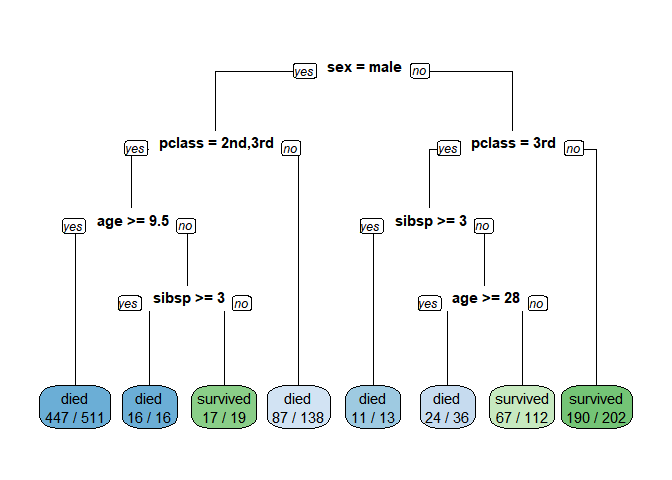

```r
rpart.plot(x = titanic_model, yesno = 2, type = 0, extra = 2)
```

> Regressão Logística

A seguir, ajustaremos um modelo de regressão logística para prever a variável Survived, com base em todas as outras colunas do titanic_train .

```r
modelolog=glm(survived~. ,  data = titanic_train, family = binomial)
anova(modelolog, test="Chisq")
```

```
## Analysis of Deviance Table
##
## Model: binomial, link: logit
##
## Response: survived
##
## Terms added sequentially (first to last)
##
##
##        Df Deviance Resid. Df Resid. Dev  Pr(>Chi)
## NULL                     834    1133.63
## pclass  2  102.637       832    1031.00 < 2.2e-16 ***
## sex     1  242.247       831     788.75 < 2.2e-16 ***
## age     1   26.311       830     762.44 2.906e-07 ***
## sibsp   1    8.724       829     753.71   0.00314 **
## parch   1    1.212       828     752.50   0.27087
## ---
## Signif. codes:  0 '***' 0.001 '**' 0.01 '*' 0.05 '.' 0.1 ' ' 1
```

```r
print(modelolog)
```

```
##
## Call:  glm(formula = survived ~ ., family = binomial, data = titanic_train)
##
## Coefficients:
## (Intercept)    pclass2nd    pclass3rd      sexmale          age
##     4.15595     -1.45940     -2.50458     -2.63641     -0.04102
##       sibsp        parch
##    -0.36562      0.12598
##
## Degrees of Freedom: 834 Total (i.e. Null);  828 Residual
##   (212 observations deleted due to missingness)
## Null Deviance:       1134
## Residual Deviance: 752.5     AIC: 766.5
```

Adotando um nível de significância de $5\%$ , é possível afirmar que apenas a variável *parch* não é significativa no modelo.

A partir do modelo de regressão logística ajustado, vamos calcular a razão de chances:

```r
exp(coef(modelolog))
```

```
## (Intercept)   pclass2nd   pclass3rd     sexmale         age       sibsp
## 63.81256916  0.23237477  0.08171015  0.07161759  0.95980591  0.69376414
##       parch
##  1.13426400
```

> Previsão
- Árvore de Classificação

  ```r
  head(predict(titanic_model, titanic_test))
  ```

  ```
  ##          died  survived
  ## 4  0.63043478 0.3695652
  ## 8  0.63043478 0.3695652
  ## 17 0.63043478 0.3695652
  ## 19 0.05940594 0.9405941
  ## 23 0.63043478 0.3695652
  ## 27 0.63043478 0.3695652
  ```

  ```r
  head(predict(titanic_model, titanic_test, type="class"))
  ```

  ```
  ##        4        8       17       19       23       27
  ##     died     died     died survived     died     died
  ## Levels: died survived
  ```

- Regressão Logística

  ```r
  head(predict(modelolog, titanic_test))
  ```

  ```
  ##           4           8          17          19          23          27
  ##  0.17515469 -0.08040773  0.66093907  2.84317616  0.45290672  0.12830767
  ```

> Medidas de Avaliação

Sabendo que a acurácia consiste na proporção de acertos, vamos analisar o acerto do modelo utilizando o pacote *caret* .

```r
class_prediction=predict(titanic_model, titanic_test, type="class")
confusionMatrix(data = class_prediction, reference = titanic_test$survived)
```

```
## Confusion Matrix and Statistics
##
##           Reference
## Prediction died survived
##   died      143       29
##   survived   22       68
##
##                Accuracy : 0.8053
##                  95% CI : (0.7521, 0.8515)
##     No Information Rate : 0.6298
##     P-Value [Acc > NIR] : 5.273e-10
##
##                   Kappa : 0.5763
##  Mcnemar's Test P-Value : 0.4008
##
##             Sensitivity : 0.8667
##             Specificity : 0.7010
##          Pos Pred Value : 0.8314
##          Neg Pred Value : 0.7556
##              Prevalence : 0.6298
##          Detection Rate : 0.5458
##    Detection Prevalence : 0.6565
##       Balanced Accuracy : 0.7838
##
##        'Positive' Class : died
##
```